# Project 350B: Analysing Ames Housing Dataset

Anish Mohan

March 15, 2017

## Analysing Ames Housing Dataset.

Credit: This data was was obtained from https://ww2.amstat.org/publications/jse/v19n3/decock.pdf and is also available as part of Kaggle Competition: https://www.kaggle.com/c/house-prices-advanced-regression-techniques

### 1. Introduction

The Ames Housing data contains data related to houses bought and sold in Ames, Iowa between 2006 and 2010. This dataset contains information about 1451 houses. For each house, this data set has information of about 81 varialbes/features.The features includes common aspects of house like Area of the Lot, Area of the house, Number of bathrooms etc. It also includes some uncommon aspects of house like the Masonary Veneer type, 3 Season porch etc. The intent here is to study the dataset and find out they key factors that contribute to the Sale price of the house.

### 2. Overview and Summary of Results

In this report, I have done exploratory data analysis on the housing data from Ames,Iowa and tried to idenitify the key parameters that impact the house Sale price. Here are some key findings from this report:

- Characterstics of the House played a significant role compared to the location of the house in Ames, Iowa.The only exception to this is the NridgeHt community which commands a higher Sale Price compared to other communities.
- Many parameters had strong correlation and formed a good predictive variable for the Sale price. E.g the overall Quality of the house seems to take into account the size of the house, number of bathrooms, number of bedrooms, Rooms above grade etc. Hence the overall quanity of the house was a strong indicator of the Sale price of the house.
- A house with a larger area generally has more bedrooms, bathrooms, garage capacity and basement area and hence generally fetches a higher price.
- Newer houses had higher quality rating than older houses.
- Most of the houses sold in Ames, Iowa were Single family homes and most of the houses were between 1000-3000 SqFt. Additionally most of the homes had 2 full baths and the garage capacity for 2 cars.
- Some of the features also seem to have higher impact on the Sale Price. Example Central Air system, Poured Concrete Foundation etc.
- Using linear methods (Linear Regression, Stepwise Regression, SVD Regression and Elastic Net) for predicting the house Sale Price seems to be fairly effective with the general accuracy being in 1-5% and the Adj $R^2$ being around 92-93%.
- Key variables which are good indicators of the Sale Price are:
  - Overall Quality of the house.
  - House Area -> This is correlated to Garage Capacity, Garage Area, Greater Living Room Area, Number of bedrooms, Number of bathrooms etc.
  - Land factors: Zoning, Lot Area, Land Contours etc.
  - Heating/Cooling System, Central Air.
  - Roofing and Foundation Material
- The key variables that we measured and which do not have significant impact on the data set are
  - Class and Shape of the Land.
  - Roof Styles.
  - Various kinds of Masonary
  - Conditions of Basement
  - Month and Year of Selling the house and type of sale.
  - Sale Conditions
  - Paved Drive
  - Results of Regression Analyis

### 3. Exploratory Data Analysis

In the given data, about half of the features are Quantitiative variables and the remaining ones are Categorical variables. There are many houses that do not have all the feature information available. Also there are many features or variables which are only available for small number of houses.

In this analysis, we will consider the House Sale Price as the dependent variable and rest of the variables being independent variables.

```r
#Loading the libraries and the data
library(ggplot2)
library(reshape2)
library(MASS)
house = read.csv("train.csv", header = TRUE, stringsAsFactors = FALSE)
house[complete.cases(house),]
```

```
##  [1] Id            MSSubClass    MSZoning      LotFrontage   LotArea
##  [6] Street        Alley         LotShape      LandContour   Utilities
## [11] LotConfig     LandSlope     Neighborhood  Condition1    Condition2
## [16] BldgType      HouseStyle    OverallQual   OverallCond   YearBuilt
## [21] YearRemodAdd  RoofStyle     RoofMatl      Exterior1st   Exterior2nd
## [26] MasVnrType    MasVnrArea    ExterQual     ExterCond     Foundation
## [31] BsmtQual      BsmtCond      BsmtExposure  BsmtFinType1  BsmtFinSF1
## [36] BsmtFinType2  BsmtFinSF2    BsmtUnfSF     TotalBsmtSF   Heating
## [41] HeatingQC     CentralAir    Electrical    X1stFlrSF     X2ndFlrSF
## [46] LowQualFinSF  GrLivArea     BsmtFullBath  BsmtHalfBath  FullBath
## [51] HalfBath      BedroomAbvGr  KitchenAbvGr  KitchenQual   TotRmsAbvGrd
## [56] Functional    Fireplaces    FireplaceQu   GarageType    GarageYrBlt
## [61] GarageFinish  GarageCars    GarageArea    GarageQual    GarageCond
## [66] PavedDrive    WoodDeckSF    OpenPorchSF   EnclosedPorch X3SsnPorch
## [71] ScreenPorch   PoolArea      PoolQC        Fence         MiscFeature
## [76] MiscVal       MoSold        YrSold        SaleType      SaleCondition
## [81] SalePrice
## <0 rows> (or 0-length row.names)
```

```r
# names(house)
dim(house)
```

```
## [1] 1460   81
```

```r
# str(house)
```

Since some variables are only available for small number of houses, for the purpose of the analysis here, I have removed them as they would not have significant impact on most of the houses. I do understand the implication here that such variable might be a good predictor for the dependent variable:- House Sale Price

```r
todrop = c("Fence", "MiscFeature","PoolQC","GarageType","GarageQual","GarageCond", "GarageFinish","GarageYrBlt",
           "FireplaceQu", "BsmtFinType1", "BsmtFinType2", "BsmtExposure","BsmtQual","BsmtCond","Alley","LotFrontage","Condition2")
house[,todrop] = NULL
house = na.omit(house)

house.int = house[,c("MSSubClass","LotArea","OverallQual","OverallCond",
                      "MasVnrArea","BsmtFinSF1","BsmtFinSF2","BsmtUnfSF","TotalBsmtSF",
                     "X1stFlrSF","X2ndFlrSF","LowQualFinSF","GrLivArea","BsmtFullBath",
                     "BsmtHalfBath","FullBath","HalfBath","BedroomAbvGr","KitchenAbvGr",
                     "TotRmsAbvGrd","Fireplaces","GarageCars","GarageArea",
                     "WoodDeckSF","OpenPorchSF","EnclosedPorch","X3SsnPorch","PoolArea",
                     "MiscVal","MoSold","YrSold","SalePrice")]
```

Summary of the housing data shows some interesting results in the distribution of the features. For e.g

- Lot Are of the house has a huge variation and can vary from 1300 Sq Ft to 200,000Sq Ft. The lot area for the some of the houses are smaller than the Basement area of some of the other houses.
- There is a subjective measurement of Overall Quality of the house that rates from 1 to Max Quality of 10 with the median about 6. Another subjective measurement is the Overall Condition of the house that varies from 1 to 9 with the median about 5.
- Most houses have atleast 1 room. However, some houses are sold even without any bathrooms or half bathrooms.
- The Sale price has a huge variance going from about$ 35K to $755K

```r
summary(house.int)
```

```
##    MSSubClass        LotArea        OverallQual      OverallCond
##  Min.   : 20.00   Min.   :  1300   Min.   : 1.000   Min.   :1.00
##  1st Qu.: 20.00   1st Qu.:  7538   1st Qu.: 5.000   1st Qu.:5.00
##  Median : 50.00   Median :  9477   Median : 6.000   Median :5.00
##  Mean   : 56.93   Mean   : 10508   Mean   : 6.094   Mean   :5.58
##  3rd Qu.: 70.00   3rd Qu.: 11600   3rd Qu.: 7.000   3rd Qu.:6.00
##  Max.   :190.00   Max.   :215245   Max.   :10.000   Max.   :9.00
##    MasVnrArea       BsmtFinSF1       BsmtFinSF2        BsmtUnfSF
##  Min.   :   0.0   Min.   :   0.0   Min.   :   0.00   Min.   :   0.0
##  1st Qu.:   0.0   1st Qu.:   0.0   1st Qu.:   0.00   1st Qu.: 222.0
##  Median :   0.0   Median : 381.0   Median :   0.00   Median : 479.0
##  Mean   : 103.8   Mean   : 442.3   Mean   :  46.84   Mean   : 567.2
##  3rd Qu.: 166.0   3rd Qu.: 707.0   3rd Qu.:   0.00   3rd Qu.: 808.0
##  Max.   :1600.0   Max.   :5644.0   Max.   :1474.00   Max.   :2336.0
##   TotalBsmtSF     X1stFlrSF      X2ndFlrSF       LowQualFinSF
##  Min.   :   0   Min.   : 334   Min.   :   0.0   Min.   :  0.000
##  1st Qu.: 795   1st Qu.: 882   1st Qu.:   0.0   1st Qu.:  0.000
##  Median : 991   Median :1086   Median :   0.0   Median :  0.000
##  Mean   :1056   Mean   :1162   Mean   : 346.7   Mean   :  5.881
##  3rd Qu.:1298   3rd Qu.:1391   3rd Qu.: 728.0   3rd Qu.:  0.000
##  Max.   :6110   Max.   :4692   Max.   :2065.0   Max.   :572.000
##    GrLivArea     BsmtFullBath     BsmtHalfBath        FullBath
##  Min.   : 334   Min.   :0.0000   Min.   :0.00000   Min.   :0.000
##  1st Qu.:1128   1st Qu.:0.0000   1st Qu.:0.00000   1st Qu.:1.000
##  Median :1464   Median :0.0000   Median :0.00000   Median :2.000
##  Mean   :1514   Mean   :0.4238   Mean   :0.05789   Mean   :1.562
##  3rd Qu.:1776   3rd Qu.:1.0000   3rd Qu.:0.00000   3rd Qu.:2.000
##  Max.   :5642   Max.   :3.0000   Max.   :2.00000   Max.   :3.000
##     HalfBath       BedroomAbvGr    KitchenAbvGr    TotRmsAbvGrd
##  Min.   :0.0000   Min.   :0.000   Min.   :0.000   Min.   : 2.000
##  1st Qu.:0.0000   1st Qu.:2.000   1st Qu.:1.000   1st Qu.: 5.000
##  Median :0.0000   Median :3.000   Median :1.000   Median : 6.000
##  Mean   :0.3811   Mean   :2.867   Mean   :1.046   Mean   : 6.517
##  3rd Qu.:1.0000   3rd Qu.:3.000   3rd Qu.:1.000   3rd Qu.: 7.000
##  Max.   :2.0000   Max.   :8.000   Max.   :3.000   Max.   :14.000
##    Fireplaces       GarageCars      GarageArea       WoodDeckSF
##  Min.   :0.0000   Min.   :0.000   Min.   :   0.0   Min.   :  0.00
##  1st Qu.:0.0000   1st Qu.:1.000   1st Qu.: 327.5   1st Qu.:  0.00
##  Median :1.0000   Median :2.000   Median : 478.0   Median :  0.00
##  Mean   :0.6127   Mean   :1.765   Mean   : 472.5   Mean   : 94.41
##  3rd Qu.:1.0000   3rd Qu.:2.000   3rd Qu.: 576.0   3rd Qu.:168.00
##  Max.   :3.0000   Max.   :4.000   Max.   :1418.0   Max.   :857.00
##   OpenPorchSF     EnclosedPorch      X3SsnPorch         PoolArea
##  Min.   :  0.00   Min.   :  0.00   Min.   :  0.000   Min.   :  0.000
##  1st Qu.:  0.00   1st Qu.:  0.00   1st Qu.:  0.000   1st Qu.:  0.000
##  Median : 24.00   Median :  0.00   Median :  0.000   Median :  0.000
##  Mean   : 46.42   Mean   : 21.95   Mean   :  3.431   Mean   :  2.776
##  3rd Qu.: 68.00   3rd Qu.:  0.00   3rd Qu.:  0.000   3rd Qu.:  0.000
##  Max.   :547.00   Max.   :552.00   Max.   :508.000   Max.   :738.000
##     MiscVal             MoSold           YrSold       SalePrice
##  Min.   :    0.00   Min.   : 1.000   Min.   :2006   Min.   : 34900
##  1st Qu.:    0.00   1st Qu.: 5.000   1st Qu.:2007   1st Qu.:129900
##  Median :    0.00   Median : 6.000   Median :2008   Median :162500
##  Mean   :   43.76   Mean   : 6.319   Mean   :2008   Mean   :180624
##  3rd Qu.:    0.00   3rd Qu.: 8.000   3rd Qu.:2009   3rd Qu.:214000
##  Max.   :15500.00   Max.   :12.000   Max.   :2010   Max.   :755000
```

#### Analysing Histogram Distributions of data

Histogram of Sale distribution shows a peak around $150K, with a long tail going upto $750K

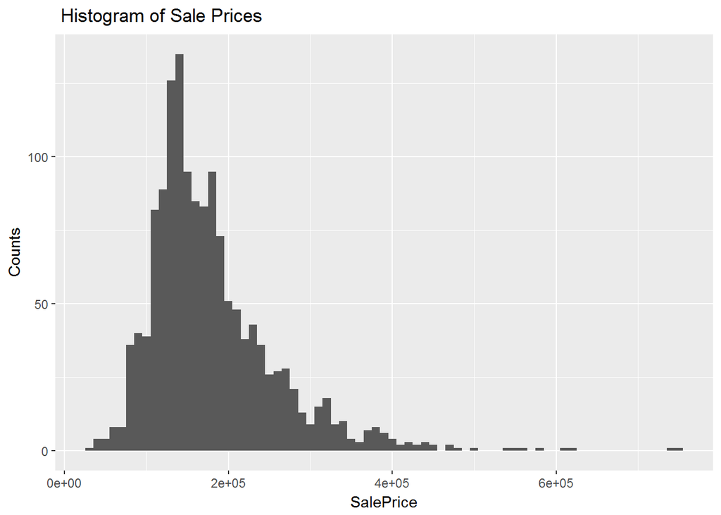

```r
ggplot(house, aes(SalePrice)) + geom_histogram(binwidth = 10000) + xlab("SalePrice") + ylab("Counts") + ggtitle(" Histogram of Sale Prices")
```

Histogram of the Quality Ratings shows that most Houses have a quality rating of 5 or 6.

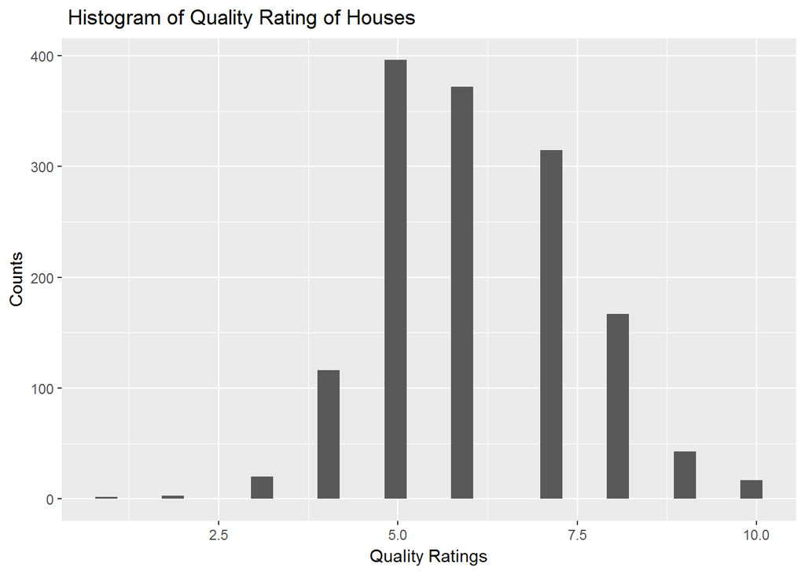

```r
ggplot(house, aes(OverallQual)) + geom_histogram() + xlab("Quality Ratings") + ylab("Counts") + ggtitle(" Histogram of Quality Rating of Houses")
```

Histogram for the total housing area shows a very broad peak of about 1000-2000 Square feet.

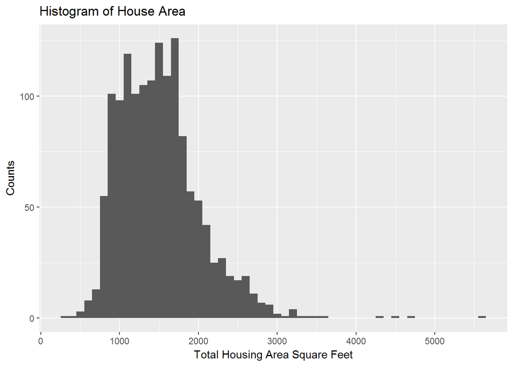

```r
ggplot(house, aes(X1stFlrSF+X2ndFlrSF)) + geom_histogram(binwidth = 100) + xlab("Total Housing Area Square Feet") + ylab("Counts") + ggtitle("Histogram of House Area")
```

Histogram of Garage distribution shows that most of the sold houses have garage capacity of 2 Cars

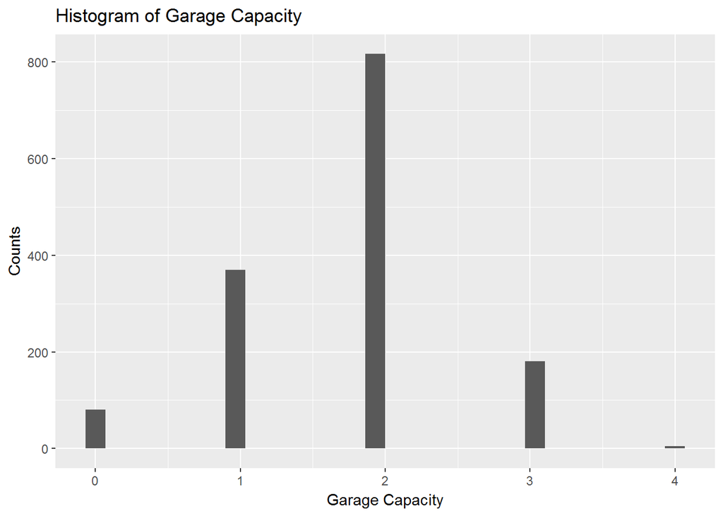

```r
ggplot(house, aes(GarageCars)) + geom_histogram() + xlab("Garage Capacity") + ylab("Counts") + ggtitle("Histogram of Garage Capacity")
```

Similar to Garage Capacity, the distribution of # of full baths show that most houses have 2 baths.

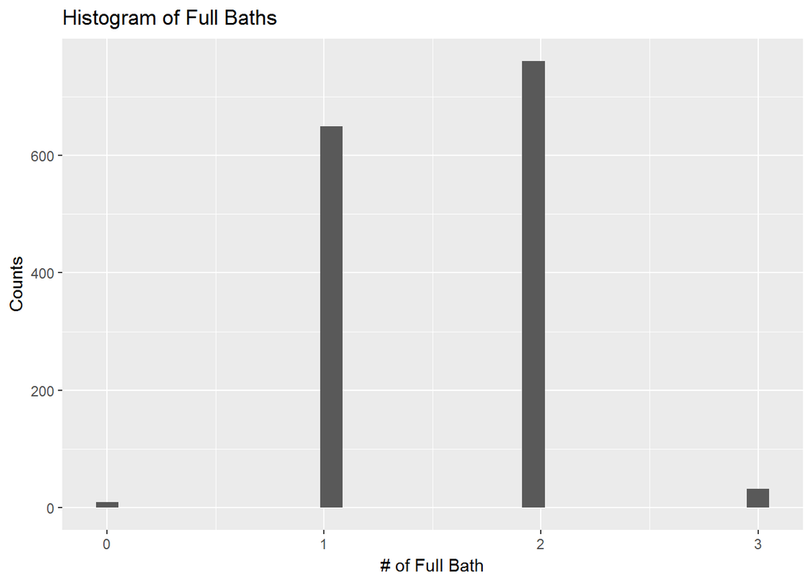

```r
ggplot(house, aes(FullBath)) + geom_histogram() + xlab("# of Full Bath") + ylab("Counts") + ggtitle("Histogram of Full Baths")
```

Looking at distriubtion of Buidling types, Single Family houses are the most common houses that sold.

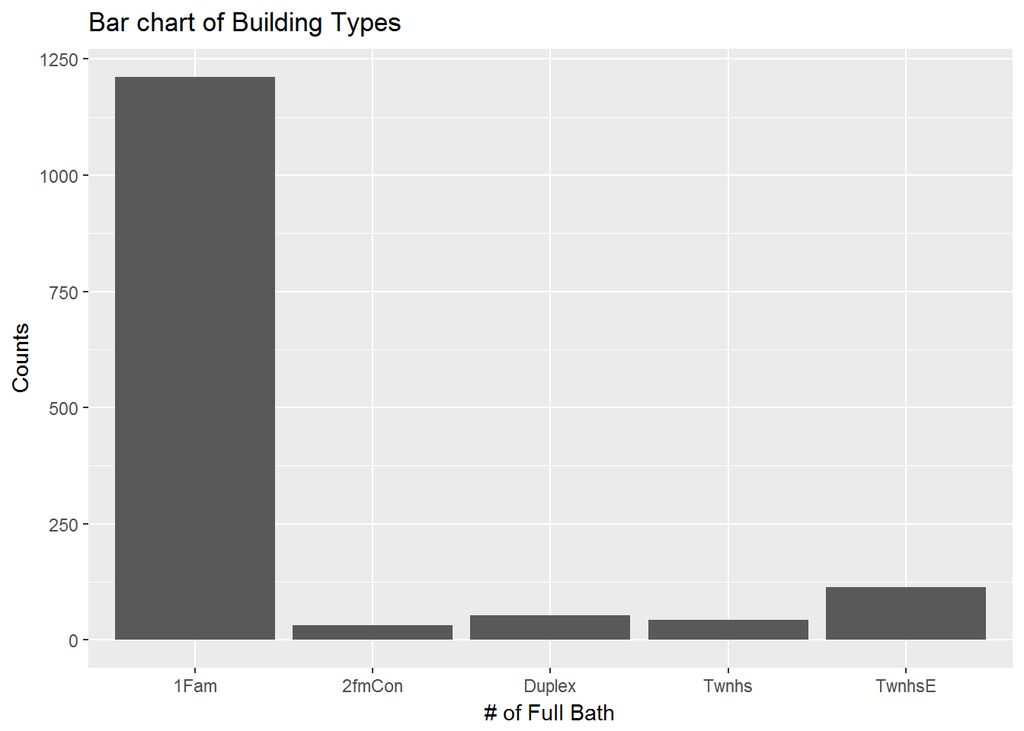

```r
ggplot(house, aes(BldgType)) + geom_bar() + xlab("# of Full Bath") + ylab("Counts") + ggtitle("Bar chart of Building Types")
```

This bar chart shows that 1 and 2 story houses are the most common. In such houses both the 1st and 2nd level of the houses are finished.

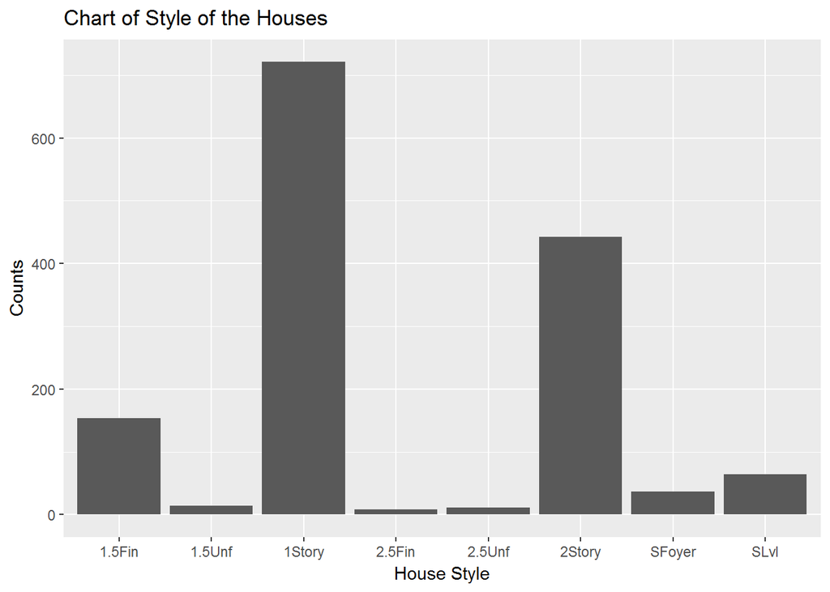

```r
ggplot(house, aes(HouseStyle)) + geom_bar() + xlab("House Style") + ylab("Counts") + ggtitle("Chart of Style of the Houses")
```

The distribution of the ZOning of the sold houses show that most houses sold are in the Residential Low Density Zones.

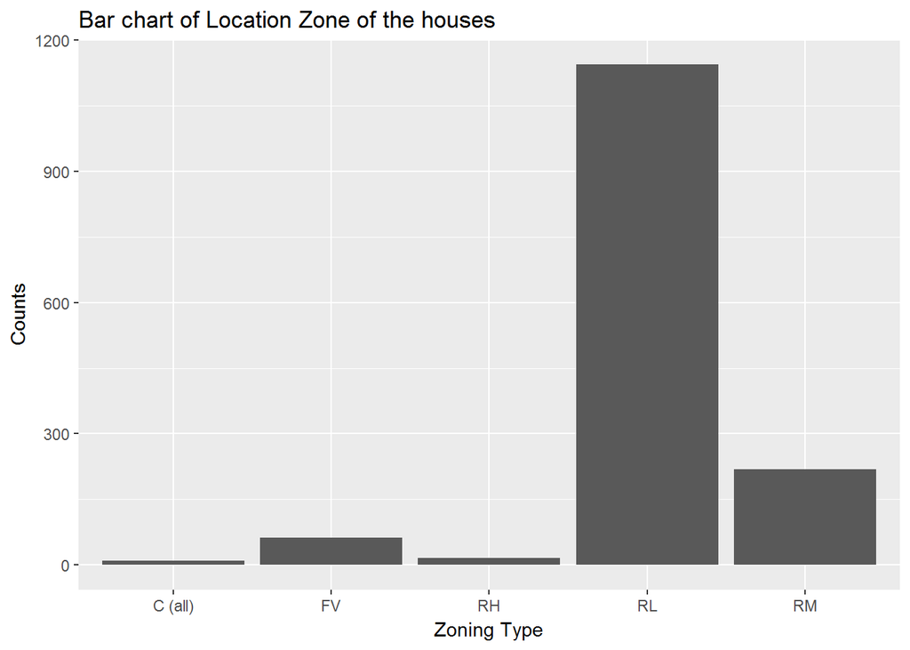

```r
ggplot(house, aes(MSZoning)) + geom_bar() + xlab("Zoning Type") + ylab("Counts") + ggtitle("Bar chart of Location Zone of the houses")
```

#### Analysing Covariance/Correation between variables.

Analysis of co-variance and correlations show that houses built in latter years have higher quality rating. The overall quality rating also seems to be higher when the houses are larger having bigger basement and living areas. Such houses are also sold at higher Sale price.

Sale Price seeems to be impacted by overall the size of the house. Basically, if the house has larger area, it also means that it has larger 1st floor area, Living area and Basement area etc.

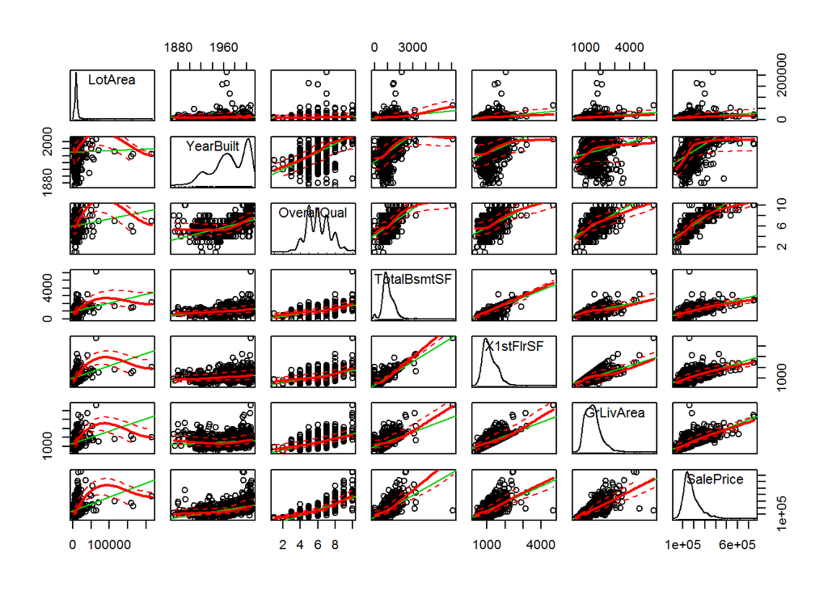

```r
options(repr.plot.width=16, repr.plot.height=16)
require(car)
scatterplotMatrix(~LotArea + YearBuilt+ OverallQual + TotalBsmtSF + X1stFlrSF + GrLivArea  +SalePrice, data = house)
```

Second set of factors that seem to impact Sale price is the number of Bedrooms. Bathrooms and higher capacity garages.

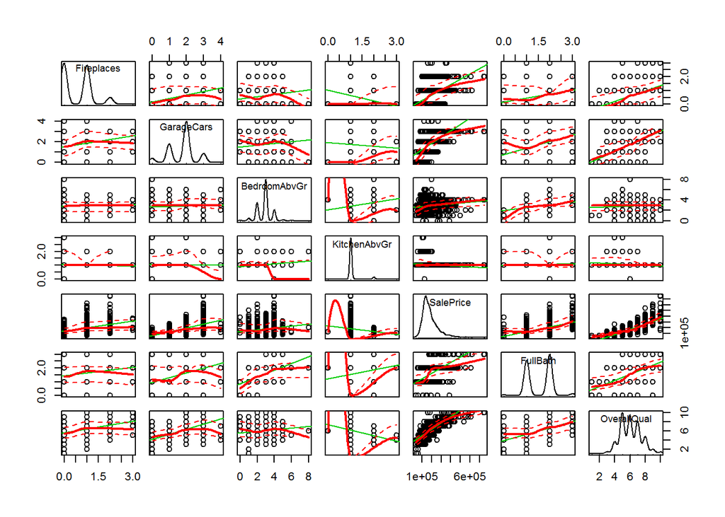

#### Correlation Plots

This correlation plot shows that there is positive correlation of Overall Quality, Total Basement Area, 1St Floor Area, Greater Living area, Number of full baths, Total Rooms, Number ofFireplaces, Garage Area etc.

There also seems to be correlation on the charactersitcs of the home i.e a home with larger 1st floor area has higher total basement area, living area , garage area etc.

```r
library(ellipse)
R = cor(house[, c("MSSubClass","LotArea","OverallQual","OverallCond",
                  "TotalBsmtSF","X1stFlrSF","GrLivArea","FullBath","HalfBath","BedroomAbvGr","KitchenAbvGr","TotRmsAbvGrd","Fireplaces","GarageCars","GarageArea",
                  "WoodDeckSF","OpenPorchSF","EnclosedPorch","X3SsnPorch","PoolArea",
                  "SalePrice")], method = 'pearson')
#print(R)
options(repr.plot.width=50, repr.plot.height=50)
Lab.palette <- colorRampPalette(c("red", "orange", "blue"),
                                space = "Lab")
```

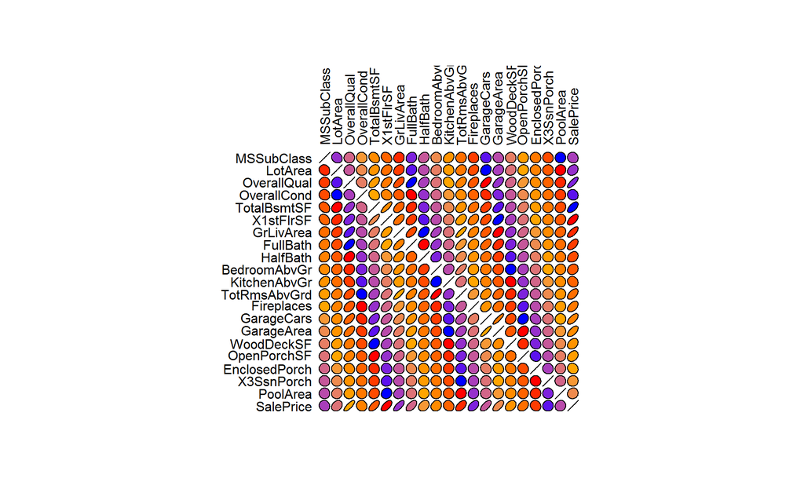

```r
plotcorr(R, col = Lab.palette(25))
```

This correlation plot shows that there is positive correlation of Overall Quality, Total Basement Area, 1St Floor Area, Greater Living area, Number of full baths, Total Rooms, Number ofFireplaces, Garage Area etc.

There also seems to be correlation on the charactersitcs of the home i.e a home with larger 1st floor area has higher total basement area, living area , garage area etc.

Also, this shows that a house with higher overall quality generally has larger living size and generally fetches higher price.

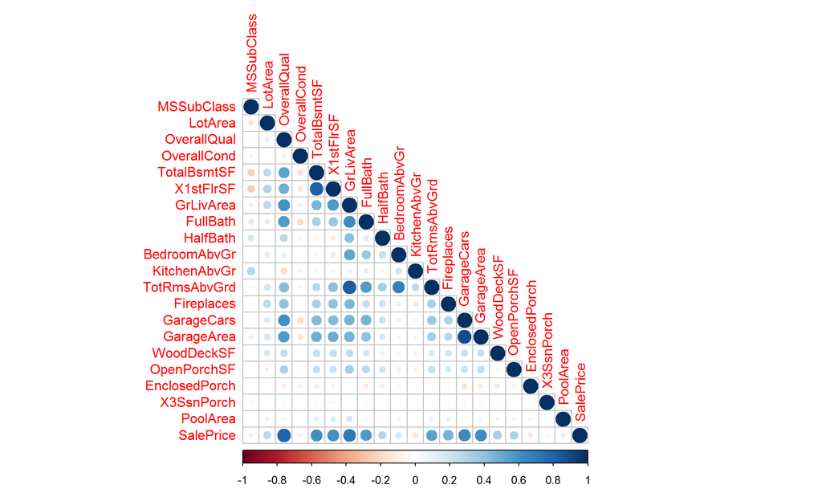

```r
library(corrplot)
corrplot(R, method="circle", type='lower')
```

#### Comparing impact of specific variables to Sales Price

This comparison shows that Houses with Central air system sell at higher price than houses without central air.

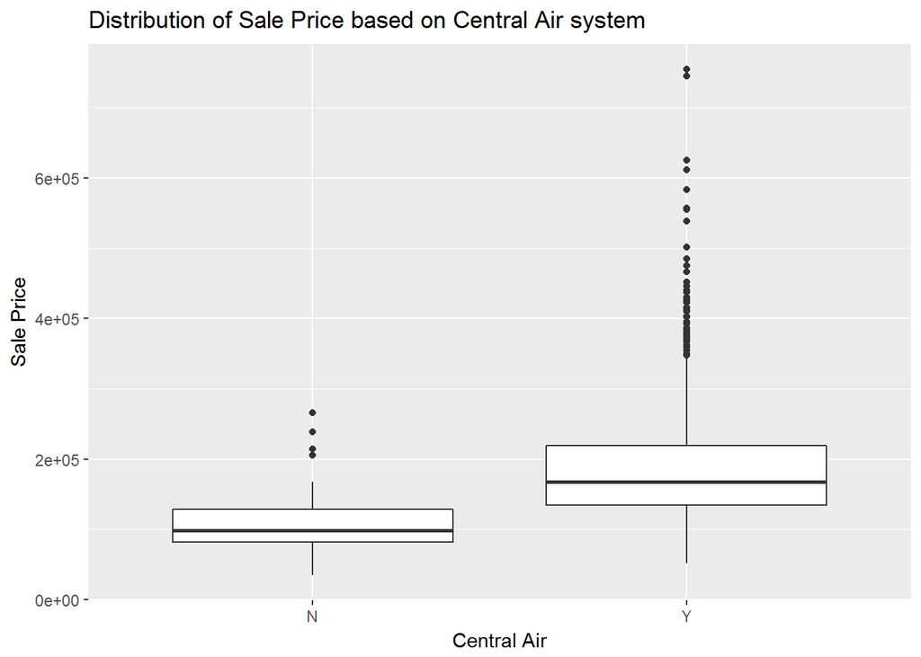

```r
ggplot(house, aes(x = factor(CentralAir), y = SalePrice)) + geom_boxplot() + xlab("Central Air") + ylab("Sale Price") + ggtitle("Distribution of Sale Price based on Central Air system")
```

This chart shows that Sales price is uniform among building types, but there is a lot of variation in Single Family homes compared to other building types

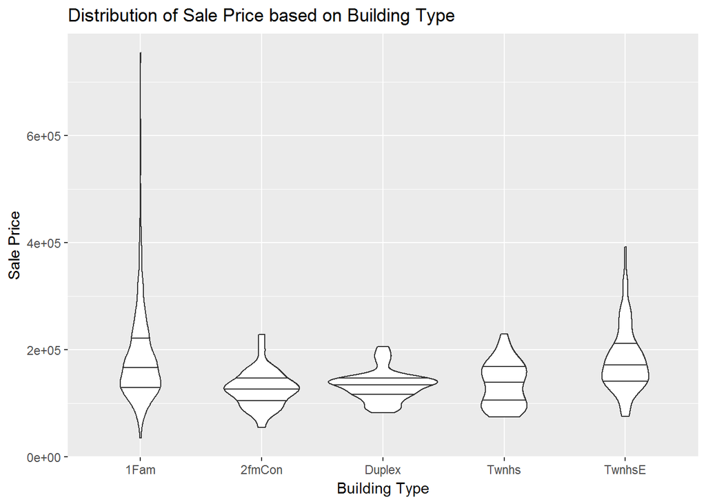

```r
ggplot(house, aes(x = factor(BldgType), y = SalePrice)) + geom_violin(trim = T, draw_quantiles = c(0.25,0.5,0.75)) + xlab("Building Type") + ylab("Sale Price") + ggtitle("Distribution of Sale Price based on Building Type")
```

This chart shows that houses with wood shingle roof generally prefer high prices compared to Composite shingle roof or Tar Gravel roof

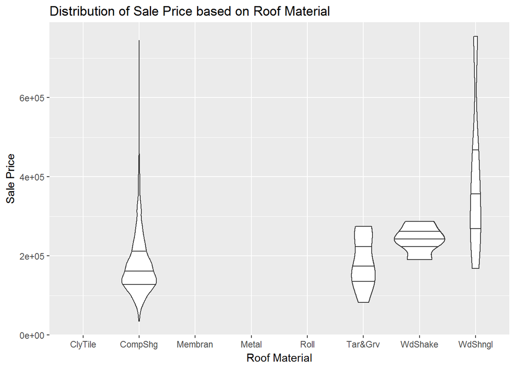

```r
ggplot(house, aes(x = factor(RoofMatl), y = SalePrice)) + geom_violin(trim = T, draw_quantiles = c(0.25,0.5,0.75)) + xlab("Roof Material") + ylab("Sale Price") + ggtitle("Distribution of Sale Price based on Roof Material")
```

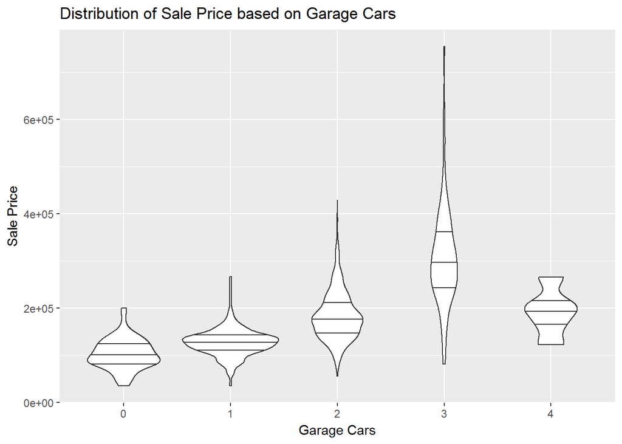

```r
ggplot(house, aes(x = factor(GarageCars), y = SalePrice)) + geom_violin(trim = T, draw_quantiles = c(0.25,0.5,0.75)) + xlab("Garage Cars") + ylab("Sale Price") + ggtitle("Distribution of Sale Price based on Garage Cars")
```

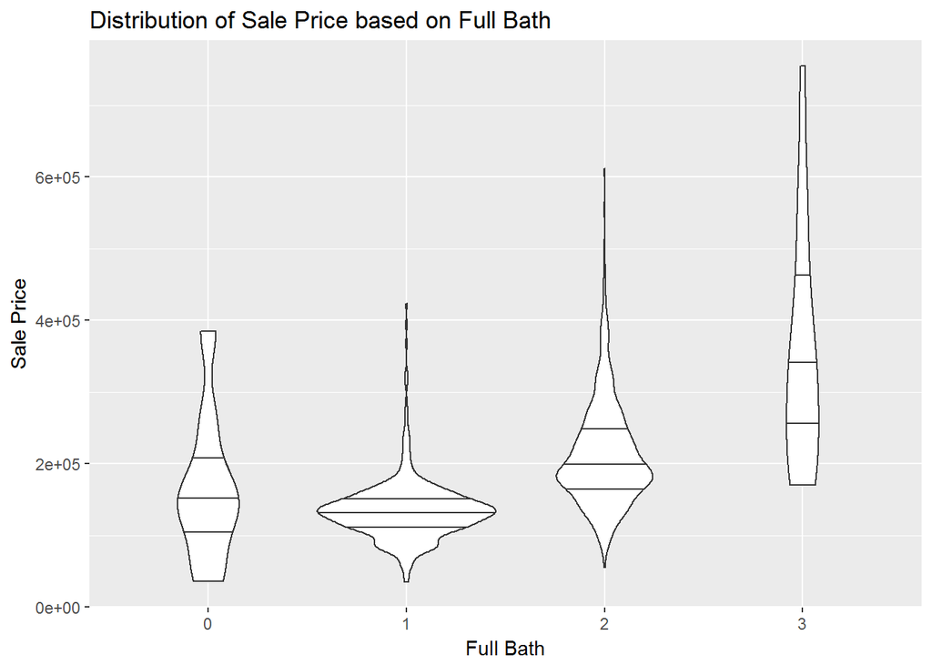

```r
ggplot(house, aes(x = factor(FullBath), y = SalePrice)) + geom_violin(trim = T, draw_quantiles = c(0.25,0.5,0.75)) + xlab("Full Bath") + ylab("Sale Price") + ggtitle("Distribution of Sale Price based on Full Bath")
```

This chart shows that houses with higher quality rating have are sold at higher prices

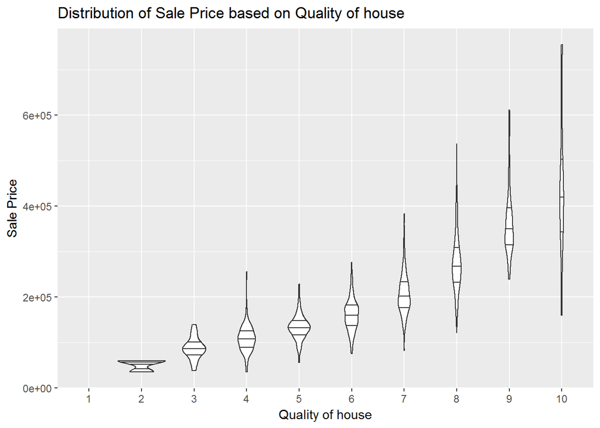

```r
ggplot(house, aes(x = factor(OverallQual), y = SalePrice)) + geom_violin(trim = T, draw_quantiles = c(0.25,0.5,0.75)) + xlab("Quality of house") + ylab("Sale Price") + ggtitle("Distribution of Sale Price based on Quality of house")
```

#### Point Distribution of paried variables.

This distribution clearly shows that houses on RM Zone (Residential Medium Denisity) have lower lot area and generally have lower sales price

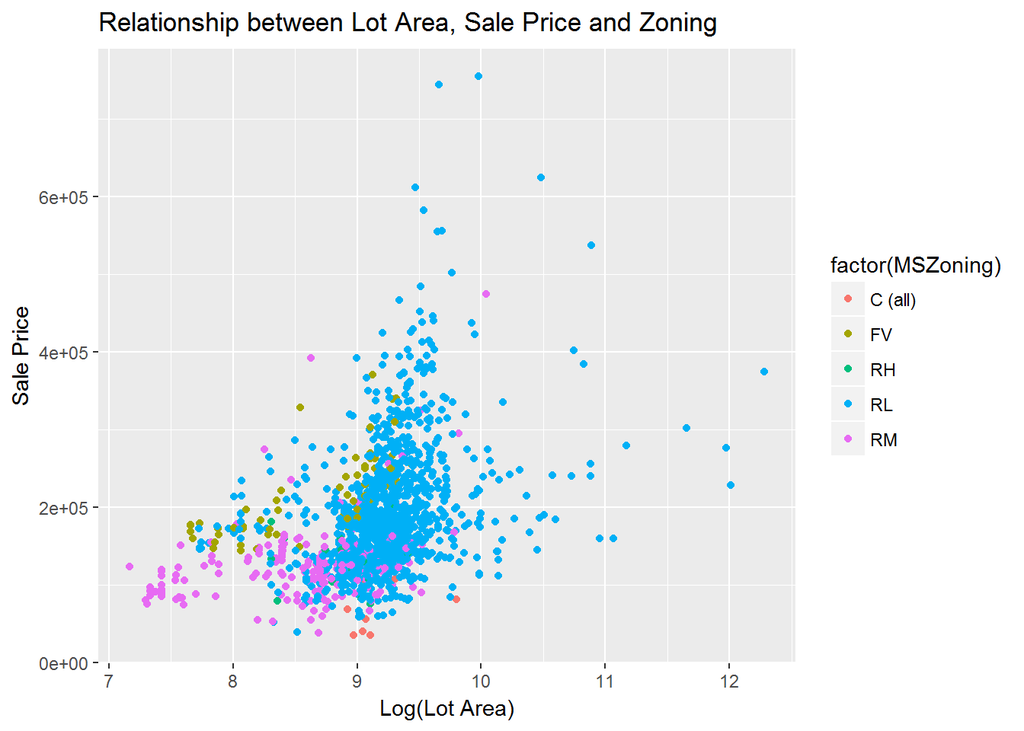

```r
ggplot(house, aes(y = SalePrice, x = log(LotArea))) + geom_point(aes(color= factor(MSZoning))) + xlab("Log(Lot Area)") + ylab("Sale Price") + ggtitle("Relationship between Lot Area, Sale Price and Zoning")
```

This distribution chart shows that generally Townhomes are on lower lot area and feth lower prices. However End unit townhouses fetch comparable prices to single family homes

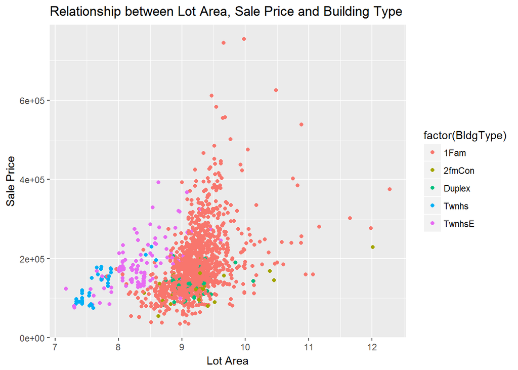

```r
ggplot(house, aes(y = SalePrice, x = log(LotArea))) + geom_point(aes(color= factor(BldgType))) + xlab("Lot Area") + ylab("Sale Price") + ggtitle("Relationship between Lot Area, Sale Price and Building Type ")
```

This chart clearly shows that houses that are built in later years are geneally more expensive even if they might have the same area

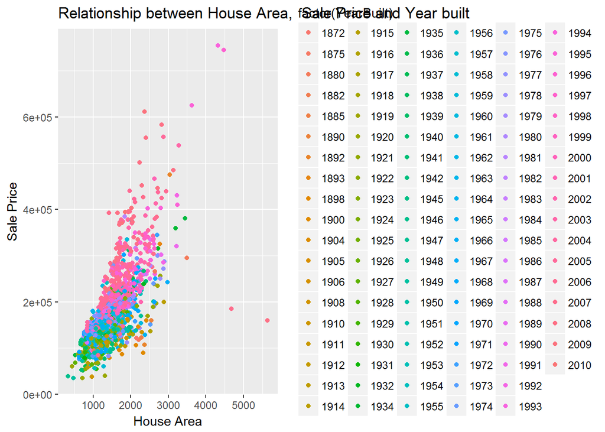

```r
ggplot(house, aes(y = SalePrice, x = (X1stFlrSF+X2ndFlrSF))) + geom_point(aes(color= factor(YearBuilt))) + xlab("House Area") + ylab("Sale Price") + ggtitle("Relationship between House Area,  Sale Price and Year built")
```

This chart shows that foundation impacts the price of the house and the most expensive houses have pourded concrete foundation.

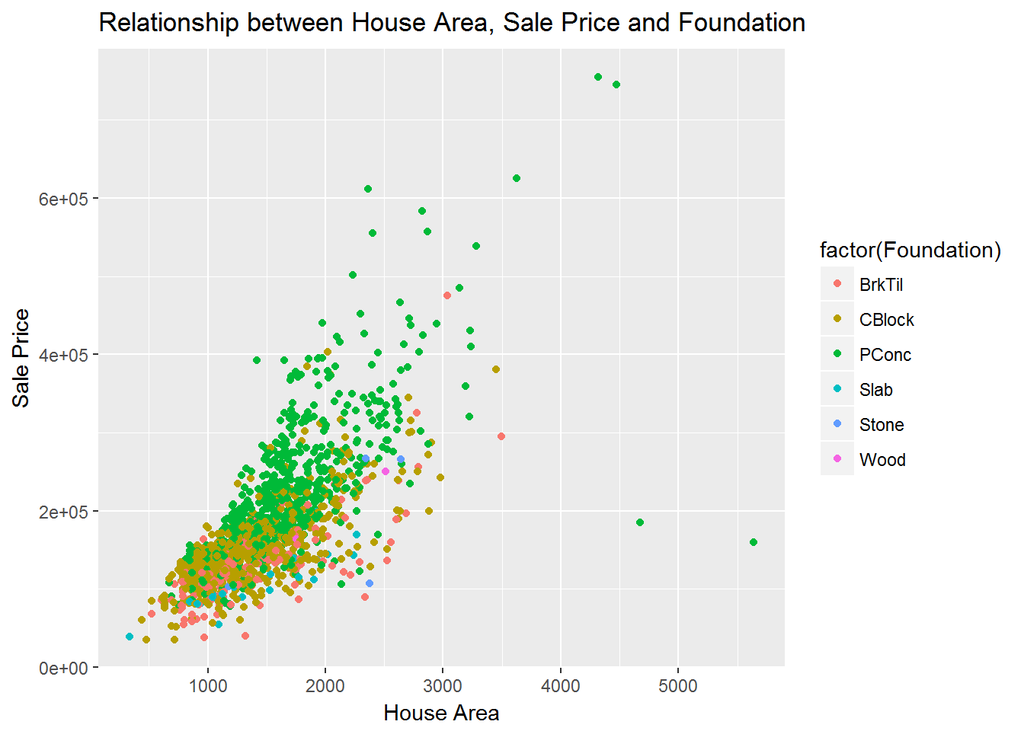

```r
ggplot(house, aes(y = SalePrice, x = (X1stFlrSF + X2ndFlrSF))) + geom_point(aes(color= factor(Foundation))) + xlab("House Area") + ylab("Sale Price") + ggtitle("Relationship between House Area, Sale Price and Foundation")
```

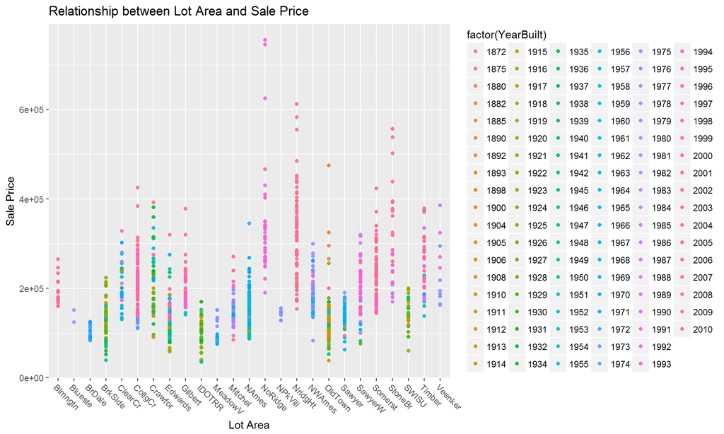

```r
ggplot(house, aes(y = SalePrice, x = Neighborhood)) + geom_point(aes(color= factor(YearBuilt)), alpha = 0.9) + xlab("Lot Area") + ylab("Sale Price") + ggtitle("Relationship between Lot Area and Sale Price") +
  theme(axis.text.x=element_text(angle = -45, hjust = 0))
```

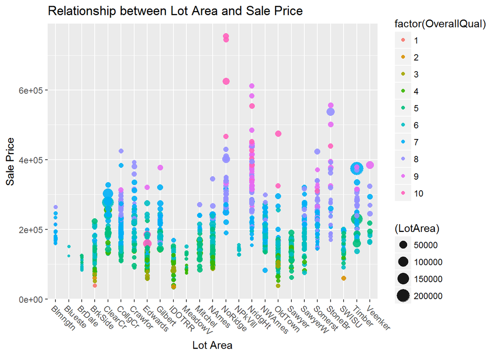

```r
ggplot(house, aes(y = SalePrice, x = Neighborhood)) + geom_point(aes(color= factor(OverallQual), size = (LotArea)), alpha = 0.9) + xlab("Lot Area") + ylab("Sale Price") + ggtitle("Relationship between Lot Area and Sale Price") +
  theme(axis.text.x=element_text(angle = -45, hjust = 0))
```

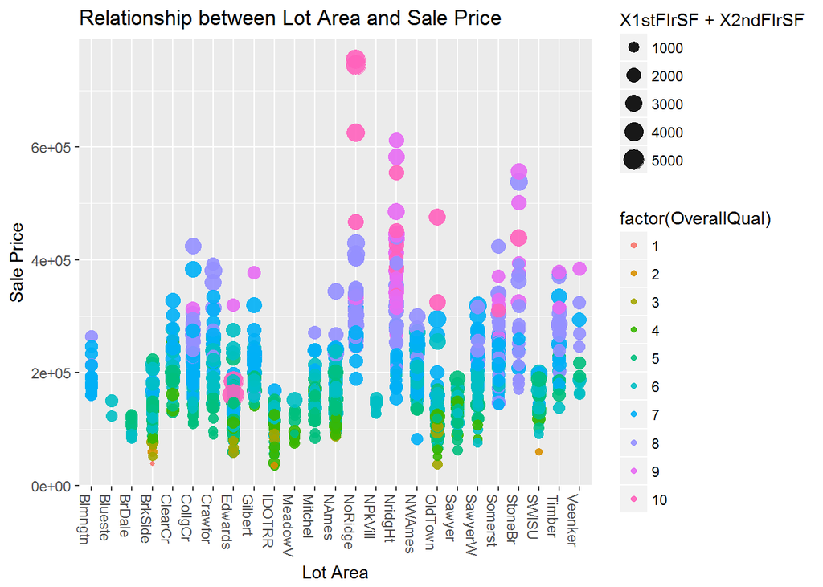

```r
ggplot(house, aes(y = SalePrice, x = Neighborhood)) + geom_point(aes(color= factor(OverallQual), size = X1stFlrSF+X2ndFlrSF), alpha = 0.9) + xlab("Lot Area") + ylab("Sale Price") + ggtitle("Relationship between Lot Area and Sale Price") +
  theme(axis.text.x=element_text(angle = -90, hjust = 0))
```

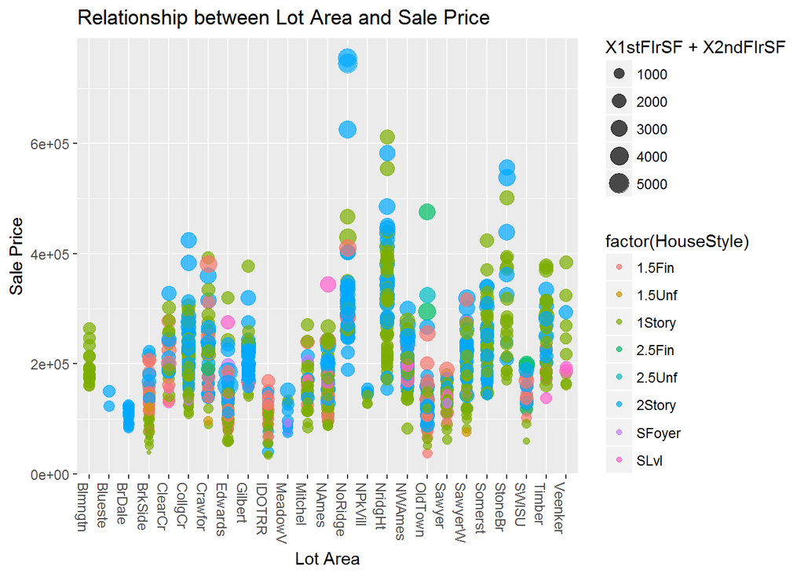

```r
ggplot(house, aes(y = SalePrice, x = Neighborhood)) + geom_point(aes(color= factor(HouseStyle), size = X1stFlrSF+X2ndFlrSF), alpha = 0.7) + xlab("Lot Area") + ylab("Sale Price") + ggtitle("Relationship between Lot Area and Sale Price") +
  theme(axis.text.x=element_text(angle = -90, hjust = 0))
```

### Regression

Results of the regression analysis shows that the following variables are good for predicting the Sale Price of the house. These variable have a p-value of <0.01

```
1.  Overall Quality of house
2.  Overall Condition of the house
3.  Year that house was built
4.  Heating
5.  Zoning
6.  Condition of House
7.  Roof Material
8.  Basement paramters
9.  Kitchen parameters
```

The final results has following parameters:

```
1.  RMSE of about 0.1099
2.  $R^2$ = 0.93
3.  Adj $R^2$ = 0.92
```

```r
#Linear Regression of the model.
house$logSalePrice = log(house$SalePrice)
lm.house = lm(logSalePrice ~.-SalePrice,data = house)
```

```r
summary(lm.house)
```

```
##
## Call:
## lm(formula = logSalePrice ~ . - SalePrice, data = house)
##
## Residuals:
##      Min       1Q   Median       3Q      Max
## -1.29433 -0.04631  0.00094  0.05470  0.46127
##
## Coefficients: (3 not defined because of singularities)
##                        Estimate Std. Error t value Pr(>|t|)
## (Intercept)           5.618e+00  4.909e+00   1.144 0.252660
## Id                   -8.153e-06  7.365e-06  -1.107 0.268486
## MSSubClass           -5.020e-04  3.920e-04  -1.281 0.200553
## MSZoningFV            4.493e-01  5.665e-02   7.930 4.77e-15 ***
## MSZoningRH            4.226e-01  5.622e-02   7.517 1.06e-13 ***
## MSZoningRL            4.212e-01  4.784e-02   8.805  < 2e-16 ***
## MSZoningRM            3.844e-01  4.482e-02   8.576  < 2e-16 ***
## LotArea               2.132e-06  4.911e-07   4.341 1.53e-05 ***
## StreetPave            1.196e-01  5.595e-02   2.138 0.032686 *
## LotShapeIR2           3.733e-02  1.978e-02   1.887 0.059370 .
## LotShapeIR3           4.827e-02  4.154e-02   1.162 0.245443
## LotShapeReg           4.003e-03  7.620e-03   0.525 0.599431
## LandContourHLS        5.993e-02  2.411e-02   2.485 0.013068 *
## LandContourLow        2.363e-02  2.974e-02   0.795 0.426984
## LandContourLvl        4.933e-02  1.745e-02   2.827 0.004778 **
## UtilitiesNoSeWa      -2.471e-01  1.224e-01  -2.020 0.043605 *
## LotConfigCulDSac      3.158e-02  1.523e-02   2.073 0.038384 *
## LotConfigFR2         -3.370e-02  1.904e-02  -1.770 0.076965 .
## LotConfigFR3         -9.190e-02  5.900e-02  -1.558 0.119569
## LotConfigInside      -1.495e-02  8.269e-03  -1.807 0.070945 .
## LandSlopeMod          4.321e-02  1.843e-02   2.345 0.019192 *
## LandSlopeSev         -9.626e-02  4.971e-02  -1.936 0.053040 .
## NeighborhoodBlueste  -4.164e-02  8.894e-02  -0.468 0.639742
## NeighborhoodBrDale   -6.615e-02  5.174e-02  -1.279 0.201296
## NeighborhoodBrkSide   3.982e-03  4.407e-02   0.090 0.928014
## NeighborhoodClearCr   2.563e-02  4.353e-02   0.589 0.556184
## NeighborhoodCollgCr  -1.905e-02  3.410e-02  -0.559 0.576468
## NeighborhoodCrawfor   1.063e-01  4.024e-02   2.641 0.008366 **
## NeighborhoodEdwards  -9.924e-02  3.770e-02  -2.632 0.008588 **
## NeighborhoodGilbert  -2.124e-02  3.655e-02  -0.581 0.561246
```

[output cut: 152 more lines]

```
## SaleTypeCWD           8.052e-02  6.128e-02   1.314 0.189033
## SaleTypeNew           1.323e-01  7.333e-02   1.804 0.071468 .
## SaleTypeOth           9.021e-02  6.886e-02   1.310 0.190412
## SaleTypeWD           -2.113e-02  1.988e-02  -1.063 0.287894
## SaleConditionAdjLand  1.171e-01  6.875e-02   1.703 0.088855 .
## SaleConditionAlloca   1.042e-01  4.188e-02   2.488 0.012962 *
## SaleConditionFamily   8.949e-03  2.895e-02   0.309 0.757271
## SaleConditionNormal   7.236e-02  1.369e-02   5.286 1.47e-07 ***
## SaleConditionPartial -3.875e-02  7.071e-02  -0.548 0.583790
## ---
## Signif. codes:  0 '***' 0.001 '**' 0.01 '*' 0.05 '.' 0.1 ' ' 1
##
## Residual standard error: 0.1099 on 1263 degrees of freedom
## Multiple R-squared:  0.9341, Adjusted R-squared:  0.9244
## F-statistic: 95.75 on 187 and 1263 DF,  p-value: < 2.2e-16
```

Plotting of various residual values show that * Residuals are mean distributed at 0. * There are some values that have high leverage and some that are outliers.

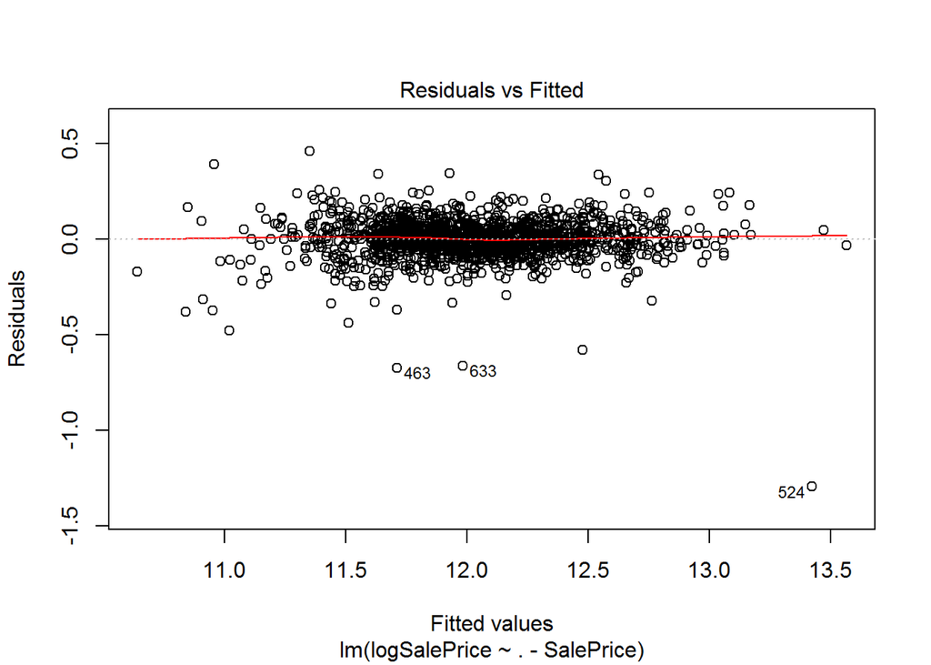

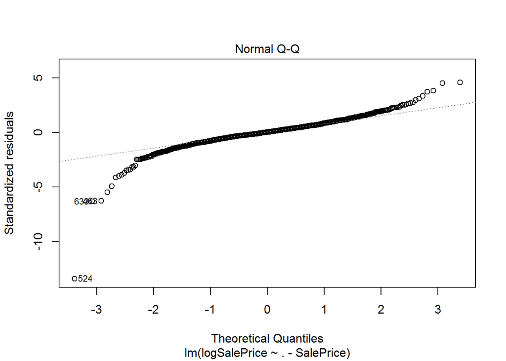

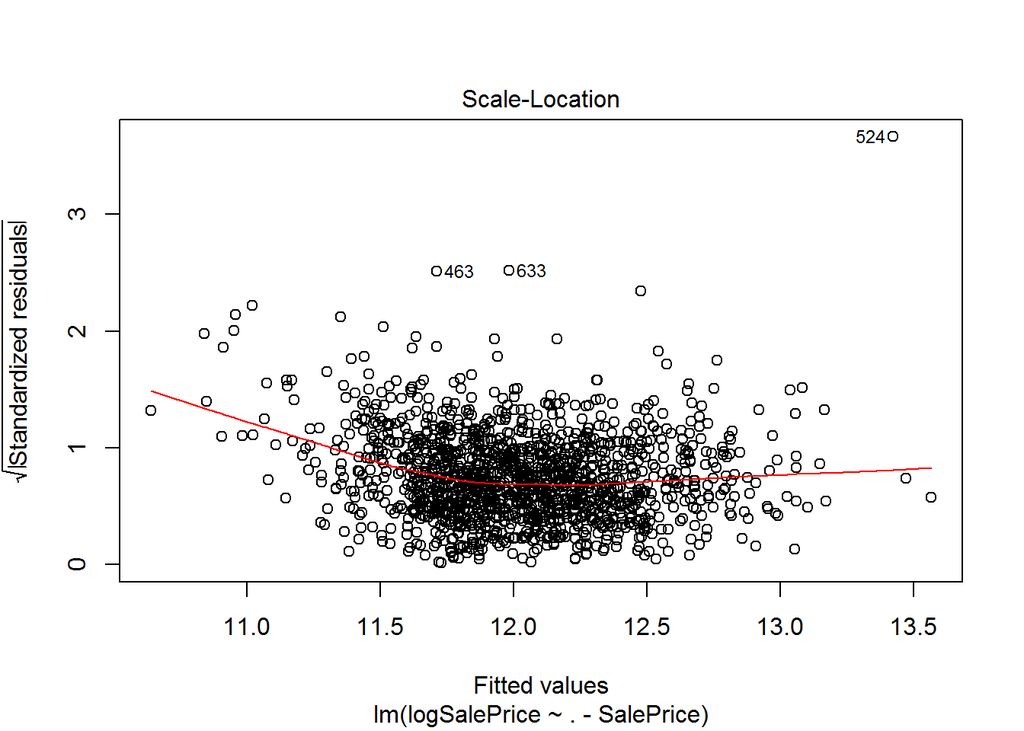

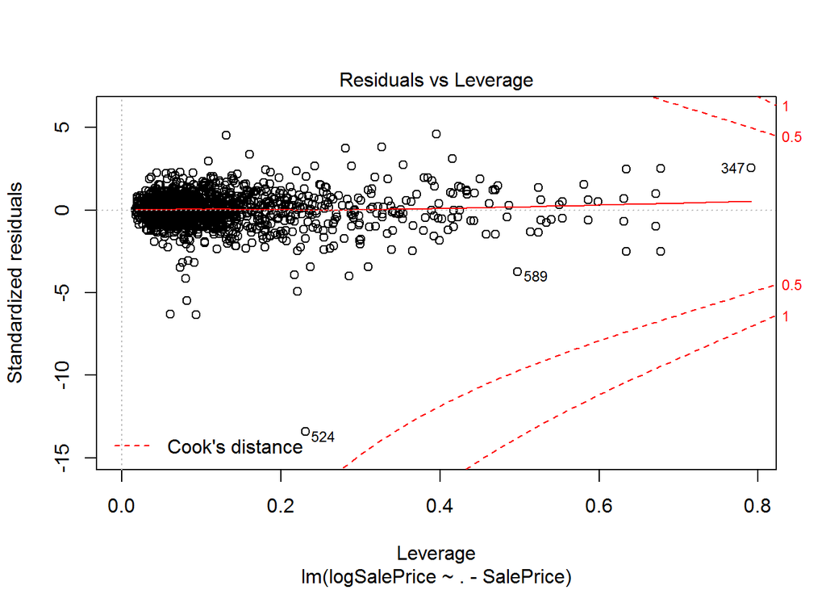

```r
plot(lm.house)
```

#### Stepwise regression

Stepwise regression shows that there is lot of correlation between the independent variable. The final model was a combination of following parameters

```
1.  Land/Lot Parameters (Contour, Utilities, Slope, Zoning etc. )
2.  Areas of various parts of the house( Lot Area, Garage Area etc )
3.  Roof Material
4.  Characterstics, Quality and Condition of the house.
5.  Number of rooms, garages, full baths, half baths.
6.  Heating and Central Air.
7.  Basement size parameters
```

Some of the parameters that were removed from the model were:

[output not shown]

```r
lm.house.aic$anova
```

```
## Stepwise Model Path
## Analysis of Deviance Table
##
## Initial Model:
## logSalePrice ~ (Id + MSSubClass + MSZoning + LotArea + Street +
##     LotShape + LandContour + Utilities + LotConfig + LandSlope +
##     Neighborhood + Condition1 + BldgType + HouseStyle + OverallQual +
##     OverallCond + YearBuilt + YearRemodAdd + RoofStyle + RoofMatl +
##     Exterior1st + Exterior2nd + MasVnrType + MasVnrArea + ExterQual +
##     ExterCond + Foundation + BsmtFinSF1 + BsmtFinSF2 + BsmtUnfSF +
##     TotalBsmtSF + Heating + HeatingQC + CentralAir + Electrical +
##     X1stFlrSF + X2ndFlrSF + LowQualFinSF + GrLivArea + BsmtFullBath +
##     BsmtHalfBath + FullBath + HalfBath + BedroomAbvGr + KitchenAbvGr +
##     KitchenQual + TotRmsAbvGrd + Functional + Fireplaces + GarageCars +
##     GarageArea + PavedDrive + WoodDeckSF + OpenPorchSF + EnclosedPorch +
##     X3SsnPorch + ScreenPorch + PoolArea + MiscVal + MoSold +
##     YrSold + SaleType + SaleCondition + SalePrice) - SalePrice
##
## Final Model:
## logSalePrice ~ MSZoning + LotArea + Street + LandContour + Utilities +
##     LotConfig + LandSlope + Neighborhood + Condition1 + BldgType +
##     OverallQual + OverallCond + YearBuilt + YearRemodAdd + RoofMatl +
##     Exterior1st + ExterCond + Foundation + BsmtFinSF1 + BsmtFinSF2 +
##     BsmtUnfSF + Heating + HeatingQC + CentralAir + X1stFlrSF +
##     X2ndFlrSF + LowQualFinSF + BsmtFullBath + FullBath + HalfBath +
##     KitchenAbvGr + KitchenQual + TotRmsAbvGrd + Functional +
##     Fireplaces + GarageCars + GarageArea + WoodDeckSF + EnclosedPorch +
##     X3SsnPorch + ScreenPorch + PoolArea + SaleType + SaleCondition
##
##
##              Step Df     Deviance Resid. Df Resid. Dev       AIC
## 1                                      1263   15.24812 -6234.106
## 2     - GrLivArea  0 0.0000000000      1263   15.24812 -6234.106
## 3   - TotalBsmtSF  0 0.0000000000      1263   15.24812 -6234.106
## 4   - Exterior2nd 14 0.1315808781      1277   15.37970 -6249.639
## 5     - RoofStyle  5 0.0426657803      1282   15.42237 -6255.619
## 6     - ExterQual  3 0.0063114188      1285   15.42868 -6261.025
## 7    - Electrical  4 0.0380993793      1289   15.46678 -6265.447
## 8    - PavedDrive  2 0.0210810403      1291   15.48786 -6267.470
## 9       - MiscVal  1 0.0005240783      1292   15.48838 -6269.421
## 10   - MasVnrArea  1 0.0018410751      1293   15.49022 -6271.249
## 11 - BsmtHalfBath  1 0.0020223081      1294   15.49225 -6273.059
## 12       - YrSold  1 0.0028774765      1295   15.49512 -6274.790
## 13     - LotShape  3 0.0484550518      1298   15.54358 -6276.259
## 14   - MasVnrType  3 0.0458185046      1301   15.58940 -6277.988
## 15       - MoSold  1 0.0090278220      1302   15.59842 -6279.148
## 16 - BedroomAbvGr  1 0.0082389555      1303   15.60666 -6280.382
## 17           - Id  1 0.0138832408      1304   15.62055 -6281.092
## 18  - OpenPorchSF  1 0.0185382931      1305   15.63908 -6281.371
## 19   - HouseStyle  7 0.1486418019      1312   15.78773 -6281.645
## 20   - MSSubClass  1 0.0004194046      1313   15.78815 -6283.607
```